# Descriptive Results

25 May, 2017

# Items:

-`MP`  
If there is a black square then there is a yellow circle.  
There is a black square.  
Conclusion: There is a yellow circle.  
- `AC`  
If there is a yellow circle then there is a black square.  
There is a black square.  
Conclusion: There is a yellow circle.  
- `MPF`  
If there is a black square then there is a yellow circle.  
There is NOT a black square.  
Conclusion: There is a yellow circle.  
- `ACF`  
If there is a yellow circle then there is a black square.  
There is NOT a black square.  
Conclusion: There is a yellow circle.  
- `CB`  
There is a black square and there is a yellow circle. / There is a yellow circle and there is a black square.  
There is a black square.  
Conclusion: There is a yellow circle.  
- `DB`  
There is a black square or there is a yellow circle. / There is a yellow circle or there is a black square.  
There is a black square.  
Conclusion: There is a yellow circle.  
- `CF`  
There is a black square and there is a yellow circle. / There is a yellow circle and there is a black square.  
There is NOT a black square.  
Conclusion: There is a yellow circle.  
- `DF`  
There is a black square or there is a yellow circle. / There is a yellow circle or there is a black square.  
There is NOT a black square.  
Conclusion: There is a yellow circle.

# First Pass

Mean first pass RTs as a function of condition:

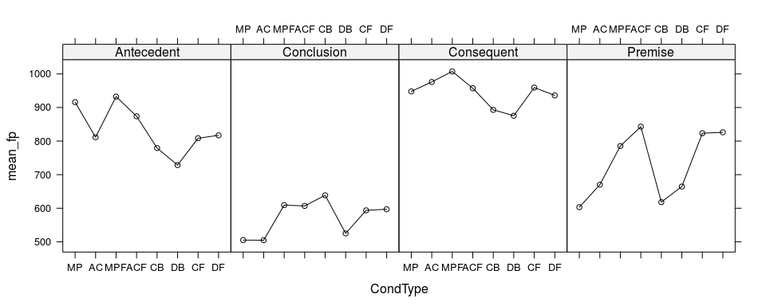

Mean first pass RTs as a function of `inference` and `polarity`:

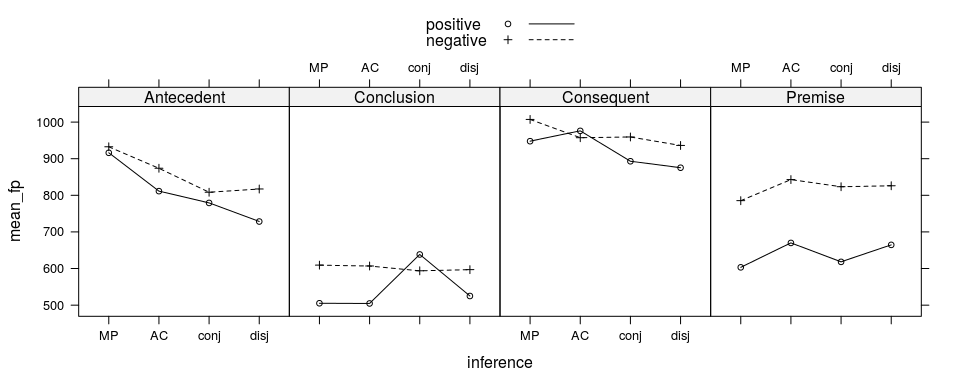

# Total Time

Mean total RTs as a function of condition:

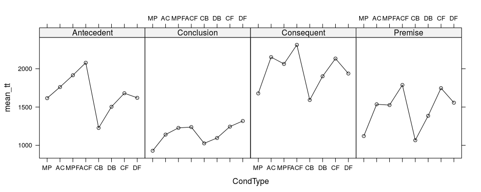

Mean total RTs as a function of `inference` and `polarity`:

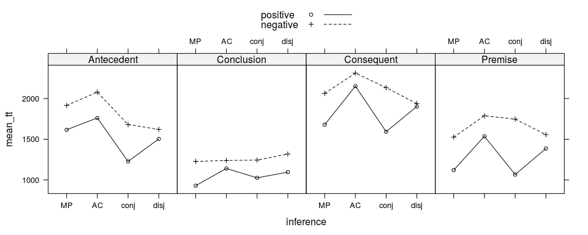

# Regression (RI)

Mean rate of RI as a function of condition:

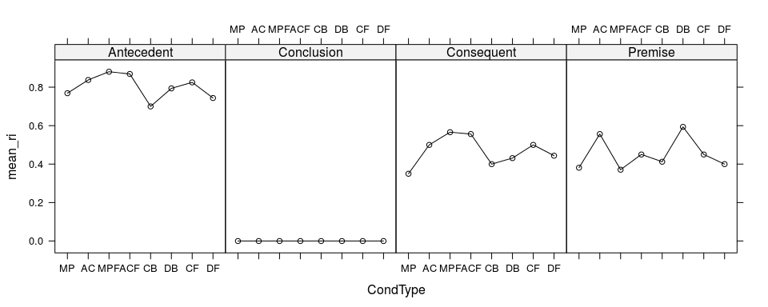

Mean rate of RI as a function of `inference` and `polarity`:

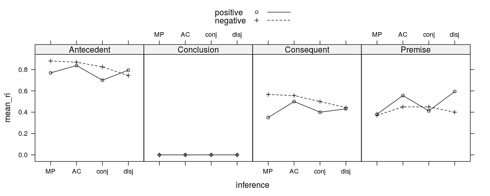

# Regression Path

Mean RP as a function of condition:

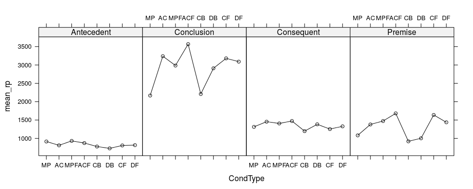

Mean RP as a function of `inference` and `polarity`:

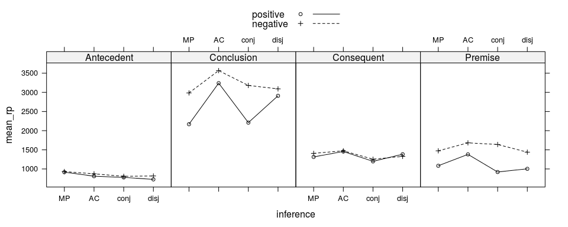

# Regression (RO)

Mean rate of RO as a function of condition:

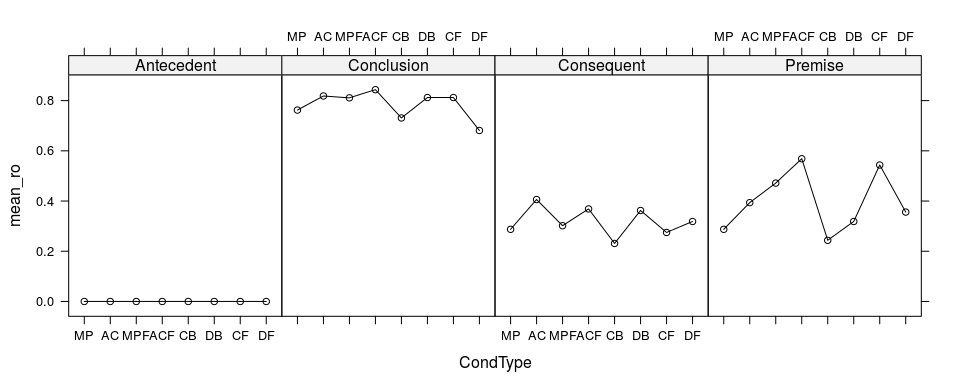

Mean rate of RO as a function of `inference` and `polarity`:

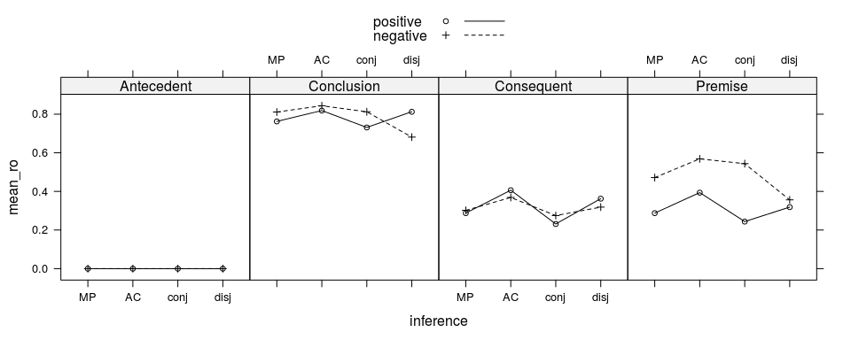